# Assignment 3: Part 2: Young People Survey

Can Aytöre / 2019702009

13/09/2020

# Second Dataset of the Assignment 3: `survey`

## Introduction

### Required Libraries

In order to examine this dataset, the following libraries are required and loaded. This dataset is not available in base-R; therefore, we need to read the dataset first as follows:

```r
library(tidyverse)
library(ggplot2)
library(corrplot) #For correlation plot
library(knitr)
#Prepare data
survey <- read.csv("~responses.csv", sep = ",") %>%
  select(History:Pets) %>%
  filter(complete.cases(.)) %>%
  tbl_df()
#Prepare PCA data
survey <- survey[,sapply(survey,class)=="integer"]
```

### Overview of Dataset

- In 2013, students of the Statistics class at FSEV UK were asked to invite their friends to participate in this survey.
- All participants were of Slovakian nationality, aged between 15-30.
- The data file consists of 886 rows and 32 columns.
- All columns are related with hobbies and interests.
- ‘1’ is NOT interested and ‘5’ is VERY interested.

```r
glimpse(survey)
```

```
## Rows: 886
## Columns: 32
## $ History                <int> 1, 1, 1, 4, 3, 5, 3, 5, 3, 3, 3, 2, 4, 2, 2,...
## $ Psychology             <int> 5, 3, 2, 4, 2, 3, 3, 2, 2, 2, 3, 2, 4, 2, 5,...
## $ Politics               <int> 1, 4, 1, 5, 3, 4, 1, 3, 1, 3, 3, 5, 4, 1, 1,...
## $ Mathematics            <int> 3, 5, 5, 4, 2, 2, 1, 1, 1, 3, 2, 1, 1, 1, 1,...
## $ Physics                <int> 3, 2, 2, 1, 2, 3, 1, 1, 1, 1, 1, 1, 1, 1, 1,...
## $ Internet               <int> 5, 4, 4, 3, 2, 4, 2, 5, 1, 5, 4, 5, 3, 3, 4,...
## $ PC                     <int> 3, 4, 2, 1, 2, 4, 1, 4, 1, 1, 5, 4, 2, 3, 2,...
## $ Economy.Management     <int> 5, 5, 4, 2, 2, 1, 3, 1, 1, 4, 3, 1, 1, 3, 3,...
## $ Biology                <int> 3, 1, 1, 3, 3, 4, 5, 2, 3, 2, 2, 1, 5, 1, 2,...
## $ Chemistry              <int> 3, 1, 1, 3, 3, 4, 5, 2, 1, 1, 1, 1, 5, 1, 1,...
## $ Reading                <int> 3, 4, 5, 5, 5, 3, 3, 2, 5, 4, 3, 3, 5, 4, 4,...
## $ Geography              <int> 3, 4, 2, 4, 2, 3, 3, 3, 1, 4, 3, 5, 3, 1, 1,...
## $ Foreign.languages      <int> 5, 5, 5, 4, 3, 4, 4, 4, 1, 5, 5, 2, 5, 5, 3,...
```

[output cut: 19 more lines]

```r
summary(survey)
```

```
##     History        Psychology       Politics      Mathematics      Physics
##  Min.   :1.000   Min.   :1.000   Min.   :1.000   Min.   :1.00   Min.   :1.000
##  1st Qu.:2.000   1st Qu.:2.000   1st Qu.:1.000   1st Qu.:1.00   1st Qu.:1.000
##  Median :3.000   Median :3.000   Median :2.000   Median :2.00   Median :2.000
##  Mean   :3.207   Mean   :3.117   Mean   :2.611   Mean   :2.37   Mean   :2.082
##  3rd Qu.:4.000   3rd Qu.:4.000   3rd Qu.:4.000   3rd Qu.:3.00   3rd Qu.:3.000
##  Max.   :5.000   Max.   :5.000   Max.   :5.000   Max.   :5.00   Max.   :5.000
##     Internet           PC       Economy.Management    Biology
##  Min.   :1.000   Min.   :1.00   Min.   :1.000      Min.   :1.000
##  1st Qu.:4.000   1st Qu.:2.00   1st Qu.:1.000      1st Qu.:1.000
##  Median :4.000   Median :3.00   Median :2.000      Median :2.000
##  Mean   :4.176   Mean   :3.13   Mean   :2.648      Mean   :2.649
##  3rd Qu.:5.000   3rd Qu.:4.00   3rd Qu.:4.000      3rd Qu.:4.000
##  Max.   :5.000   Max.   :5.00   Max.   :5.000      Max.   :5.000
##    Chemistry        Reading        Geography     Foreign.languages
##  Min.   :1.000   Min.   :1.000   Min.   :1.000   Min.   :1.000
##  1st Qu.:1.000   1st Qu.:2.000   1st Qu.:2.000   1st Qu.:3.000
##  Median :2.000   Median :3.000   Median :3.000   Median :4.000
##  Mean   :2.148   Mean   :3.163   Mean   :3.105   Mean   :3.788
##  3rd Qu.:3.000   3rd Qu.:5.000   3rd Qu.:4.000   3rd Qu.:5.000
##  Max.   :5.000   Max.   :5.000   Max.   :5.000   Max.   :5.000
##     Medicine          Law             Cars       Art.exhibitions
##  Min.   :1.000   Min.   :1.000   Min.   :1.000   Min.   :1.000
##  1st Qu.:1.000   1st Qu.:1.000   1st Qu.:1.000   1st Qu.:1.000
##  Median :2.000   Median :2.000   Median :2.000   Median :2.000
##  Mean   :2.509   Mean   :2.254   Mean   :2.658   Mean   :2.595
##  3rd Qu.:3.000   3rd Qu.:3.000   3rd Qu.:4.000   3rd Qu.:4.000
##  Max.   :5.000   Max.   :5.000   Max.   :5.000   Max.   :5.000
##     Religion     Countryside..outdoors    Dancing      Musical.instruments
##  Min.   :1.000   Min.   :1.000         Min.   :1.000   Min.   :1.000
##  1st Qu.:1.000   1st Qu.:3.000         1st Qu.:1.000   1st Qu.:1.000
##  Median :2.000   Median :4.000         Median :2.000   Median :2.000
##  Mean   :2.262   Mean   :3.675         Mean   :2.438   Mean   :2.318
##  3rd Qu.:3.000   3rd Qu.:5.000         3rd Qu.:3.000   3rd Qu.:4.000
##  Max.   :5.000   Max.   :5.000         Max.   :5.000   Max.   :5.000
##     Writing      Passive.sport    Active.sport     Gardening
##  Min.   :1.000   Min.   :1.000   Min.   :1.000   Min.   :1.000
##  1st Qu.:1.000   1st Qu.:2.000   1st Qu.:2.000   1st Qu.:1.000
##  Median :1.000   Median :4.000   Median :3.000   Median :1.000
##  Mean   :1.886   Mean   :3.412   Mean   :3.275   Mean   :1.894
##  3rd Qu.:3.000   3rd Qu.:5.000   3rd Qu.:5.000   3rd Qu.:2.750
##  Max.   :5.000   Max.   :5.000   Max.   :5.000   Max.   :5.000
##   Celebrities       Shopping     Science.and.technology    Theatre
##  Min.   :1.000   Min.   :1.000   Min.   :1.000          Min.   :1.000
##  1st Qu.:1.000   1st Qu.:2.000   1st Qu.:2.000          1st Qu.:2.000
##  Median :2.000   Median :3.000   Median :3.000          Median :3.000
##  Mean   :2.345   Mean   :3.263   Mean   :3.251          Mean   :3.026
##  3rd Qu.:3.000   3rd Qu.:4.000   3rd Qu.:4.000          3rd Qu.:4.000
##  Max.   :5.000   Max.   :5.000   Max.   :5.000          Max.   :5.000
##  Fun.with.friends Adrenaline.sports      Pets
##  Min.   :2.000    Min.   :1.000     Min.   :1.000
##  1st Qu.:4.000    1st Qu.:2.000     1st Qu.:2.000
##  Median :5.000    Median :3.000     Median :4.000
##  Mean   :4.554    Mean   :2.927     Mean   :3.326
##  3rd Qu.:5.000    3rd Qu.:4.000     3rd Qu.:5.000
##  Max.   :5.000    Max.   :5.000     Max.   :5.000
```

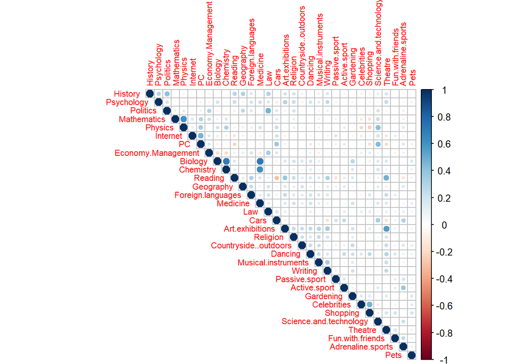

```r
corrplot(cor(survey), type="upper", tl.cex = 0.7)
```

- According to correlation plot, Biology is highly correlated with Chemistry and Medicine.
- Politics is positive correlated with Law.
- Theatre is positive correlated with Reading and Art-exhibitions.
- Reading is negative correlated with Cars.

### Objectives

- Exploring the dataset `survey`
- Examining categories that correlate with each other
- By implementing Principal Components Analysis, examining the proportion of variances and reducing the number of explanatory variables
- By applying Multidimensional Scaling, examining the relationship of ‘Hobby and Interests’ in a 2 dimensional environment
- Clustering them with K-Means Methods and Hierarchical Clustering to investigate the clusters
- By building a simple linear model, examining the relationship of ‘Biology’ with others

## Principal Components Analysis (PCA)

```r
#Do PCA with princomp function and use correlation matrix to create components
survey_pca_result <- princomp(survey, cor=TRUE)
summary(survey_pca_result, loadings = TRUE)
```

```
## Importance of components:
##                           Comp.1    Comp.2     Comp.3     Comp.4     Comp.5
## Standard deviation     2.0433958 1.8069970 1.60438109 1.46391156 1.26463164
## Proportion of Variance 0.1304833 0.1020387 0.08043871 0.06696991 0.04997791
## Cumulative Proportion  0.1304833 0.2325220 0.31296072 0.37993063 0.42990854
##                            Comp.6     Comp.7     Comp.8     Comp.9    Comp.10
## Standard deviation     1.18461175 1.06955650 1.05602251 1.04363010 1.00633062
## Proportion of Variance 0.04385328 0.03574847 0.03484949 0.03403637 0.03164692
## Cumulative Proportion  0.47376182 0.50951029 0.54435978 0.57839615 0.61004306
##                           Comp.11    Comp.12    Comp.13    Comp.14    Comp.15
## Standard deviation     0.95951254 0.93789360 0.93168719 0.89503805 0.87262765
## Proportion of Variance 0.02877076 0.02748889 0.02712628 0.02503416 0.02379622
## Cumulative Proportion  0.63881382 0.66630271 0.69342899 0.71846315 0.74225937
##                           Comp.16   Comp.17    Comp.18    Comp.19    Comp.20
## Standard deviation     0.85510068 0.8329419 0.80296355 0.78632469 0.76747805
## Proportion of Variance 0.02284991 0.0216810 0.02014845 0.01932208 0.01840695
## Cumulative Proportion  0.76510928 0.7867903 0.80693874 0.82626082 0.84466777
##                           Comp.21    Comp.22    Comp.23    Comp.24    Comp.25
## Standard deviation     0.74821762 0.72513227 0.71054805 0.70905599 0.69087699
## Proportion of Variance 0.01749468 0.01643178 0.01577745 0.01571126 0.01491597
## Cumulative Proportion  0.86216245 0.87859422 0.89437168 0.91008294 0.92499891
##                           Comp.26    Comp.27    Comp.28   Comp.29     Comp.30
## Standard deviation     0.65750430 0.64296368 0.60888823 0.5954011 0.551814415
## Proportion of Variance 0.01350975 0.01291882 0.01158578 0.0110782 0.009515598
## Cumulative Proportion  0.93850866 0.95142748 0.96301326 0.9740915 0.983607058
##                            Comp.31     Comp.32
## Standard deviation     0.539017589 0.483770803
## Proportion of Variance 0.009079374 0.007313568
## Cumulative Proportion  0.992686432 1.000000000
##
## Loadings:
##                        Comp.1 Comp.2 Comp.3 Comp.4 Comp.5 Comp.6 Comp.7 Comp.8
## History                 0.196         0.184  0.243  0.130  0.243  0.142  0.194
## Psychology              0.244                0.119  0.112        -0.102
## Politics                0.131  0.202  0.255  0.204  0.270  0.153        -0.108
## Mathematics                    0.295 -0.126  0.133        -0.309 -0.220 -0.273
## Physics                        0.344 -0.241  0.136        -0.155 -0.151 -0.151
## Internet                       0.237  0.127               -0.400         0.370
## PC                             0.377               -0.134 -0.291  0.137  0.144
## Economy.Management             0.174  0.306         0.214 -0.182 -0.166 -0.288
```

[output cut: 141 more lines]

```
## Religion               -0.111
## Countryside..outdoors
## Dancing
## Musical.instruments
## Writing                         0.150
## Passive.sport
## Active.sport
## Gardening
## Celebrities
## Shopping                0.134
## Science.and.technology
## Theatre                -0.175   0.161
## Fun.with.friends
## Adrenaline.sports
## Pets
```

- PCA is a method to reduce the number of explanatory variables. The resulting principle components (PCs) are actually linear transformations of our explanatory variables.
- For example, the second PC considers Reading, Shopping and Theatre as negative effects, and Politics, Mathematics, Physics, Internet, PC, Economy-Management, Geography, Law, Cars, Passive-sports, Active-sports, Science-and-Technology, and Adrenaline-sports as a positive effect.

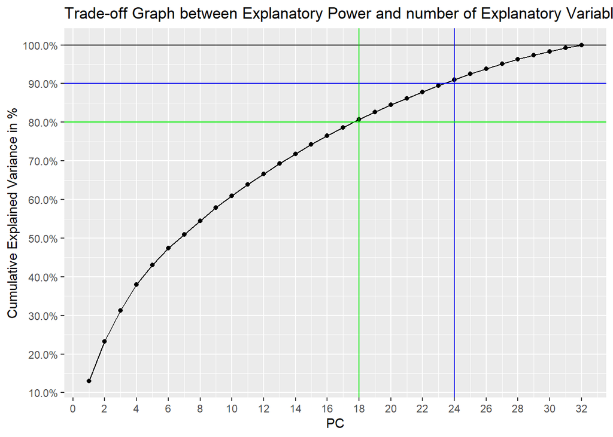

```r
ggplot(data = data.frame(PC = 1:length(survey_pca_result$sdev), var_exp = cumsum(survey_pca_result$sdev^2 / sum(survey_pca_result$sdev^2))), aes(x = PC, y = var_exp)) +
  geom_line() +
  geom_point() +
  geom_hline(yintercept = 1, color = "black") +
  geom_hline(yintercept = 0.9, color = "blue2") +
  geom_vline(xintercept = 24, color = "blue2") +
  geom_hline(yintercept = 0.8, color = "green2") +
  geom_vline(xintercept = 18, color = "green2") +
  scale_y_continuous(labels = scales::percent,breaks=seq(0,1,length.out=11)) +
  scale_x_continuous(breaks=seq(0,32,by=2)) +
  labs(title = "Trade-off Graph between Explanatory Power and number of Explanatory Variables", y = "Cumulative Explained Variance in %")
```

- As seen from the graph, the first 24 PCs are responsible for 90% **(blue hline)** of the variation.
- Resulting PCA analysis helps us to maintain 80% **(green hline)** of the variance with just *18* (out of 32) of the survey questions.
- Here we analyzed the survey results. Therefore, it will be more accurate to apply multidimensional scaling and/or hierarchical clustering to classify hobbies and interests.
- If there was an extra column in our dataset that concerns people participating in the survey (such as exam result), we could train and test our data with using the first 18 PCs (rather than 32).

## Multidimensional Scaling (MDS)

- Multidimensional scaling is a means of visualizing the level of similarity of individual cases of a dataset. MDS refers to a set of related ordination techniques used in information visualization, in particular to display the information contained in a distance matrix.
- We would like to see the how respondents preferences correlation among different ‘hobby and interests’. We are going to use the correlation matrix as a similarity measure.

```r
#Correlation is a similarity measure between -1 and 1
#Get the negative of it as a distance measure and add 1 to make sure distances start from 0
survey_dist <- 1 - cor(survey)

#Apply MDS into 2 dimensional scale
survey_mds <- cmdscale(survey_dist, k=2)

#Provide column names
colnames(survey_mds) <- c("x","y")

print(survey_mds)
```

```
##                                  x            y
## History                 0.06372563  0.012956654
## Psychology              0.23826552 -0.024422880
## Politics               -0.14749496  0.107881476
## Mathematics            -0.32345626 -0.297702691
## Physics                -0.32464296 -0.499240678
## Internet               -0.43673303  0.187118496
## PC                     -0.58516404 -0.107666761
## Economy.Management     -0.30422083  0.383264449
## Biology                 0.25483318 -0.395803325
## Chemistry               0.12745384 -0.486209735
## Reading                 0.54412403 -0.002498553
## Geography              -0.04741594  0.042633809
## Foreign.languages       0.20488850  0.223464512
## Medicine                0.21225026 -0.352629731
## Law                    -0.07751035  0.252871501
## Cars                   -0.58387376  0.046912232
## Art.exhibitions         0.37143545  0.009747048
## Religion                0.19597972 -0.174122589
## Countryside..outdoors   0.14091867 -0.071530114
## Dancing                 0.27743365  0.136486519
## Musical.instruments     0.16521053 -0.134880364
## Writing                 0.30297822 -0.032446839
## Passive.sport          -0.30096850  0.108795592
## Active.sport           -0.24240576  0.047405197
## Gardening               0.19439442 -0.077481786
## Celebrities             0.06494596  0.467218540
## Shopping                0.20807212  0.463704403
## Science.and.technology -0.36445481 -0.278443856
## Theatre                 0.44547786  0.054248884
## Fun.with.friends       -0.05316373  0.253721685
## Adrenaline.sports      -0.30291870  0.041430796
## Pets                    0.08203608  0.095218109
```

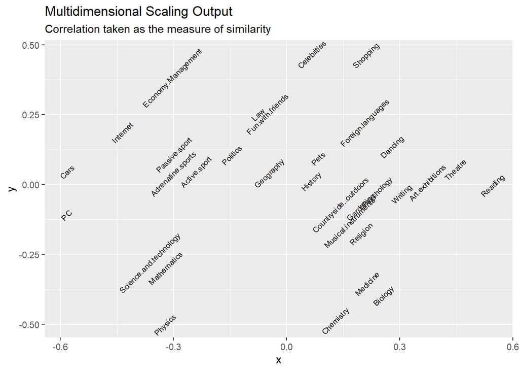

```r
#Plot
ggplot(data.frame(survey_mds), aes(x = x, y = y)) +
  geom_text(label = rownames(survey_mds), angle = 45, size = 2.7) +
  labs(title = "Multidimensional Scaling Output", subtitle = "Correlation taken as the measure of similarity")
```

- Science and Technology, and related interests (Mathematics, Physics, and PC) are clustered on the left bottom.
- On the top left, passive-sports, adrenaline-sports and active-sports goes together; Internet, Economy-Management, Politics and Cars are close.
- Pets, foreign-language, and history are loosely together on the top right.
- The remaining interests are close each other in right bottom.
- Perhaps it is not the most accurate representation, but we can see that MDS captured considerable information in just two dimensions.
- Now that we have prepared our scaling in two dimensions, we can proceed to clustering.

## K-Means

- K-Means is one of the most popular clustering algoritms.
- It is an unsupervised method. We don’t need a response variable or pre-labeled data.
- In the classical form, given a number of (say, k) clusters, the algorithm adds nodes to the clusters to minimize the variance within cluster (i.e. squared distance from the cluster center to the nodes).
- Let’s apply K-Means to the `Young People Survey` MDS output.

### Determining the Number of Cluster (k)

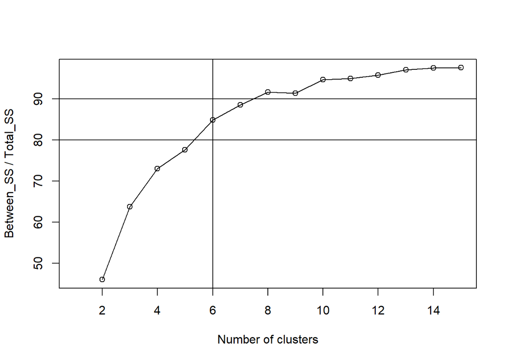

```r
set.seed(100)
sum_of_squares <- c()
for(i in 2:15){
  fit <- kmeans(survey_mds, centers = i)
  sum_of_squares[i] <- 100 * round(1-(fit$tot.withinss/fit$totss),digits = 3)
}
plot(x=1:15, y=sum_of_squares, xlab = "Number of clusters", ylab = "Between_SS / Total_SS")
lines(1:15, sum_of_squares)
abline(h=80)
abline(h=90)
abline(v=6)
```

- The total within-cluster sum of square measures the compactness (i.e goodness) of the clustering and we want it to be as small as possible.
- It would be reasonable to choose 6 clusters since the rate of increase started to decrease after that point.

### K-Means using Multidimensional Scaling Data

```r
#Set the seed since K-Means algorithm uses a search based method
set.seed(100)

#Apply K-Means
hobby_cluster <- kmeans(survey_mds, centers = 6) #k=6

#Get the clusters
mds_clusters <- data.frame(hobby = names(hobby_cluster$cluster), cluster_mds = hobby_cluster$cluster) %>%
  arrange(cluster_mds, hobby)
mds_clusters
```

```
##                                         hobby cluster_mds
## Biology                               Biology           1
## Chemistry                           Chemistry           1
## Medicine                             Medicine           1
## Active.sport                     Active.sport           2
## Adrenaline.sports           Adrenaline.sports           2
## Economy.Management         Economy.Management           2
## Fun.with.friends             Fun.with.friends           2
## Geography                           Geography           2
## Law                                       Law           2
## Passive.sport                   Passive.sport           2
## Politics                             Politics           2
## Cars                                     Cars           3
## Internet                             Internet           3
## PC                                         PC           3
## Mathematics                       Mathematics           4
## Physics                               Physics           4
## Science.and.technology Science.and.technology           4
## Celebrities                       Celebrities           5
## Foreign.languages           Foreign.languages           5
## Shopping                             Shopping           5
## Art.exhibitions               Art.exhibitions           6
## Countryside..outdoors   Countryside..outdoors           6
## Dancing                               Dancing           6
## Gardening                           Gardening           6
## History                               History           6
## Musical.instruments       Musical.instruments           6
## Pets                                     Pets           6
## Psychology                         Psychology           6
## Reading                               Reading           6
## Religion                             Religion           6
## Theatre                               Theatre           6
## Writing                               Writing           6
```

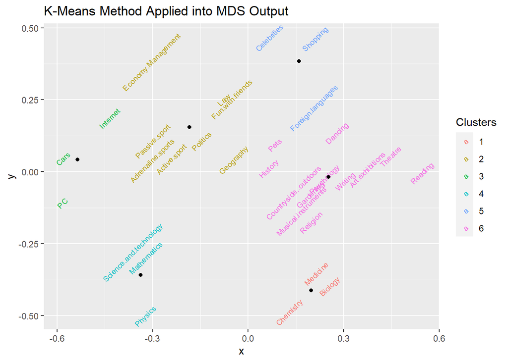

```r
#Plot the output
data.frame(survey_mds) %>%
  mutate(clusters = as.factor(hobby_cluster$cluster), hobby = rownames(survey_mds)) %>%
  ggplot(., aes(x = x, y = y)) +
  geom_text(aes(label = hobby, color = clusters), angle=45, size=2.7) +
  geom_point(data = as.data.frame(hobby_cluster$centers), aes(x=x,y=y)) +
  labs(title = "K-Means Method Applied into MDS Output", color = "Clusters")
```

- The result seems reasonable.
- For instance, Chemistry, Medicine and Biology are in same cluster.
- History, Reading, Religion, Writing and some related columns are in 6th cluster.
- Science, Maths and Physics have created a cluster far from the others. Now, We can also use the raw data (columns of survey) as follows:

### K-Means using Raw Data (columns of survey)

```r
#Set the seed because K-Means algorithm uses a search based method
set.seed(100)

#Apply K-Means to the raw data
hobby_cluster_raw <- kmeans(t(survey), centers = 6)

#Build the comparison data
compare_kmeans <- left_join(mds_clusters, data.frame(hobby = names(hobby_cluster_raw$cluster), cluster_raw = hobby_cluster_raw$cluster), by="hobby")

print(compare_kmeans)
```

```
##                     hobby cluster_mds cluster_raw
## 1                 Biology           1           1
## 2               Chemistry           1           1
## 3                Medicine           1           1
## 4            Active.sport           2           2
## 5       Adrenaline.sports           2           2
## 6      Economy.Management           2           4
## 7        Fun.with.friends           2           3
## 8               Geography           2           5
## 9                     Law           2           4
## 10          Passive.sport           2           2
## 11               Politics           2           4
## 12                   Cars           3           4
## 13               Internet           3           3
## 14                     PC           3           4
```

[output cut: 18 more lines]

- We obtained a result similar to the first clustering method where we took the correlation as the similarity measure. Although the cluster numbers vary, they are generally similar.
- Finally, let’s get survey average scores and apply K-Means again.

### K-Means using Average Scores of Raw Data

```r
#Set the seed because K-Means algorithm uses a search based method
set.seed(100)
#Prepare data (get mean scores) and apply K-Means
survey_means_data <- survey %>%
  summarise_each(funs(mean)) %>%
  t()
survey_means_data
```

```
##                            [,1]
## History                3.206546
## Psychology             3.117381
## Politics               2.610609
## Mathematics            2.370203
## Physics                2.082393
## Internet               4.176072
## PC                     3.129797
## Economy.Management     2.647856
## Biology                2.648984
## Chemistry              2.147856
## Reading                3.162528
## Geography              3.104966
## Foreign.languages      3.787810
## Medicine               2.509029
## Law                    2.253950
## Cars                   2.658014
## Art.exhibitions        2.594808
## Religion               2.261851
## Countryside..outdoors  3.674944
## Dancing                2.437923
## Musical.instruments    2.318284
## Writing                1.886005
## Passive.sport          3.411964
## Active.sport           3.275395
## Gardening              1.893905
## Celebrities            2.345372
## Shopping               3.262980
## Science.and.technology 3.250564
## Theatre                3.025959
## Fun.with.friends       4.554176
## Adrenaline.sports      2.926637
## Pets                   3.326185
```

```r
means_kmeans <- kmeans(survey_means_data, centers = 6)

#Add to compare kmeans
compare_kmeans <- left_join(compare_kmeans, data.frame(hobby = names(means_kmeans$cluster), cluster_mean = means_kmeans$cluster), by="hobby")

print(compare_kmeans)
```

```
##                     hobby cluster_mds cluster_raw cluster_mean
## 1                 Biology           1           1            4
## 2               Chemistry           1           1            6
## 3                Medicine           1           1            4
## 4            Active.sport           2           2            2
## 5       Adrenaline.sports           2           2            2
## 6      Economy.Management           2           4            4
## 7        Fun.with.friends           2           3            3
## 8               Geography           2           5            2
## 9                     Law           2           4            1
## 10          Passive.sport           2           2            2
## 11               Politics           2           4            4
## 12                   Cars           3           4            4
## 13               Internet           3           3            3
## 14                     PC           3           4            2
```

[output cut: 18 more lines]

- It seems that the latest K-Means iteration is not the best descriptive model. For instance, it clusters Economony-Management with Biology and Medicine.
- We can select the first one as the best clustering.
- Now, we will apply hierarchical clustering to easily see the variance change by changing cluster numbers.

## Hierarchical Clustering

- In Hierarchical Clustering, there are clusters within larger clusters, resulting in a tree like structure.
- There are also two types of hierarchical clustering methods, divisive (“top-down”) or agglomerative (“bottom-up”).
- The former starts with all the nodes in a cluster and splits the clusters on the way down and the latter starts merging nodes up to a single cluster.
- We’ll apply agglomerative clusters as below;

### Single Link Clustering

- Single link (or MIN) is known to minimize the closest dissimilarity between the nodes in pairwise clusters.

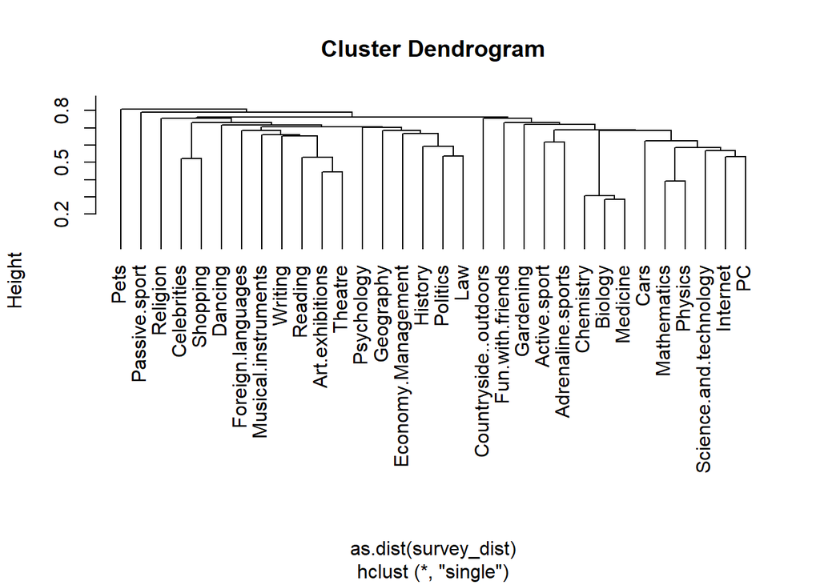

```r
### Single link (MIN) method
survey_hc_min <- hclust(as.dist(survey_dist), method="single")
plot(survey_hc_min, hang=-1)
```

- Using this method, it is not clear from where to cluster. Since the variance change is quite low between the number of clustering, we can determine higher k number.
- As expected, Biology and Medicine are in the same sub-cluster, while Chemistry joins them in one top cluster. In another top cluster, it is seen that it is related to those to the right of the graph.
- Likewise, Politics and Law merge with History in a higher cluster. Then, Economy-Management is included in the upper cluster. Geography is included in another top cluster.
- Celebrities and Shopping, Politics and Law, Theater and Art-Exhibitions, Active-sports and Adrenaline-sports, Internet and PC are located in the same sub-cluster.
- Pets doesn’t create clusters with any variables. In any case, Pets will act independently of other variables.

### Complete Link Clustering

- Complete link (or MAX) is the opposite, it wants to minimize the largest dissimilarity.

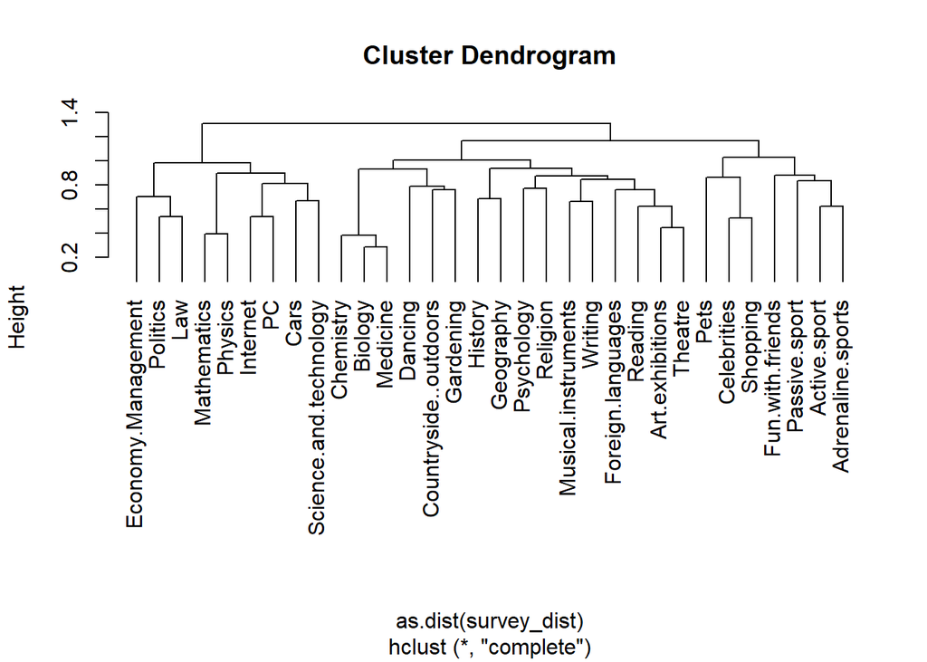

```r
### Complete link (MAX) method
survey_hc_max <- hclust(as.dist(survey_dist), method="complete")
plot(survey_hc_max, hang=-1)
```

- The variance within the group increases most when moving from number of 3 clusters to 2 clusters. For this case, it would be logical to divide it into 3 clusters.
- This time, we see Pets is paired with Celebrities and Shopping.
- On the right, the sport groups and some activities are paired together.
- On the left, we see that the science branches and the technological categories match.
- In the middle, the terms related with language, culture, lessons, habits and some daily activities are paired together.

### Average Link Clustering

- Average method aims to minimize the average distance between nodes in each cluster.

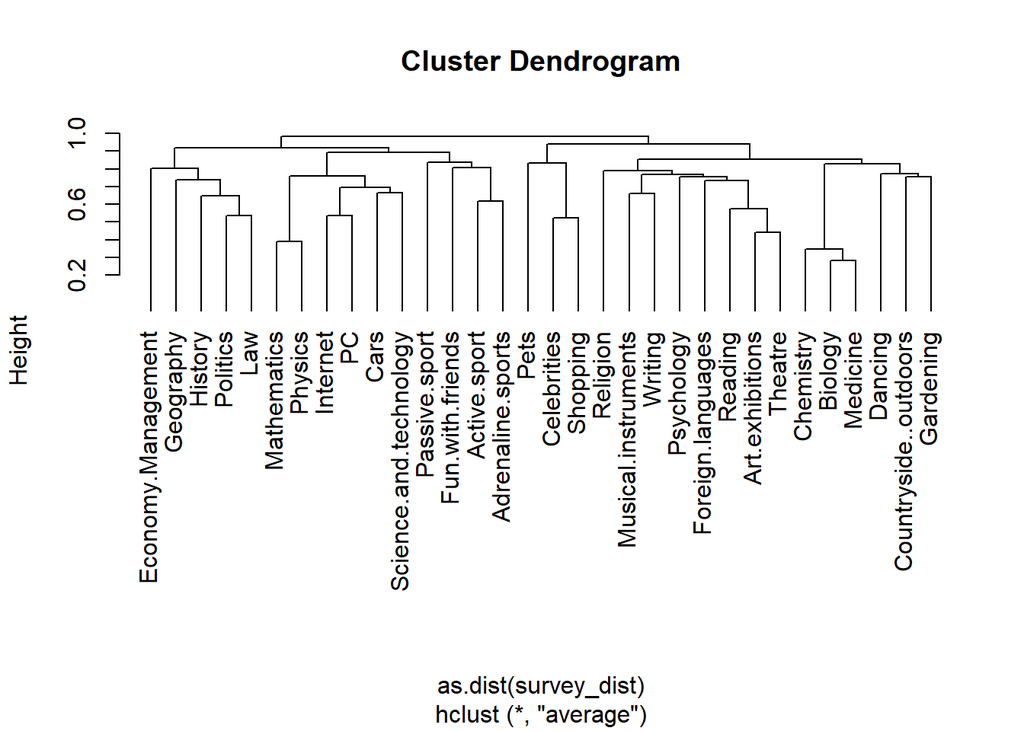

```r
### Average method
survey_hc_avg <- hclust(as.dist(survey_dist), method="average")
plot(survey_hc_avg, hang=-1)
```

- We got a result similar to the previous method.
- Here, we can keep the number k slightly higher (like 6-7).
- Thus, we can see the cluster distinctions more clearly and easily name the clusters.

## Supervised Learning

### Linear Regression

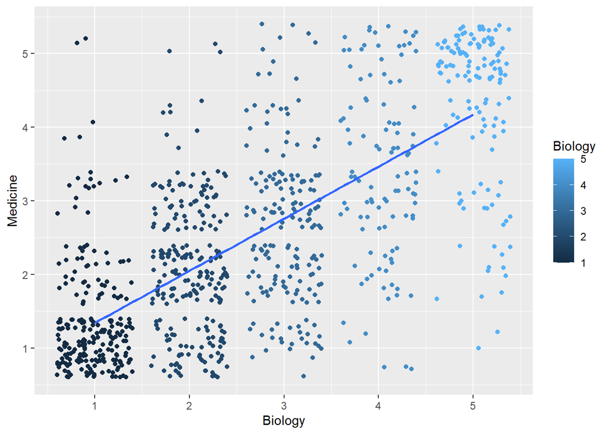

```r
#Run a simple linear regression
ggplot(data=survey) +
  geom_jitter(aes(x=Biology, y=Medicine, color=Biology)) +
  geom_smooth(method='lm',aes(x=Biology,y=Medicine),se=FALSE)
```

- We clearly see a positive trend between Biology and Medicine.
- At points where Biology is low by surveyors, Medicine also scored low. This statement is also valid in other points. Now, we will apply a linear model and see the significance level.

#### Linear Model: Biology ~ Medicine

```r
bio_vs_med <- lm(Biology ~ Medicine, data=survey)
summary(bio_vs_med)
```

```
##
## Call:
## lm(formula = Biology ~ Medicine, data = survey)
##
## Residuals:
##     Min      1Q  Median      3Q     Max
## -3.4494 -0.5583 -0.2811  0.5506  3.4417
##
## Coefficients:
##             Estimate Std. Error t value Pr(>|t|)
## (Intercept)  0.83547    0.06780   12.32   <2e-16 ***
## Medicine     0.72280    0.02375   30.44   <2e-16 ***
## ---
## Signif. codes:  0 '***' 0.001 '**' 0.01 '*' 0.05 '.' 0.1 ' ' 1
##
## Residual standard error: 0.9632 on 884 degrees of freedom
## Multiple R-squared:  0.5117, Adjusted R-squared:  0.5112
## F-statistic: 926.5 on 1 and 884 DF,  p-value: < 2.2e-16
```

- According to the summary of linear model, the p-value is very small.
- Therefore, ‘Medicine’ is significant variable in order to explain the response variable ‘Biology’. Now, we can take a glance at the relationship of Biology with other subjects by building a linear model as follows;

#### Linear Model: Biology ~ ALL

```r
#Now Biology vs all
bio_vs_all <- lm(Biology ~ ., data=survey)
summary(bio_vs_all)
```

```
##
## Call:
## lm(formula = Biology ~ ., data = survey)
##
## Residuals:
##     Min      1Q  Median      3Q     Max
## -3.5615 -0.4854 -0.0821  0.4531  3.0555
##
## Coefficients:
##                         Estimate Std. Error t value Pr(>|t|)
## (Intercept)            -0.069068   0.258427  -0.267  0.78933
## History                -0.010261   0.026593  -0.386  0.69970
## Psychology              0.101361   0.025590   3.961 8.09e-05 ***
## Politics               -0.080921   0.026817  -3.018  0.00262 **
## Mathematics            -0.007042   0.027649  -0.255  0.79902
## Physics                 0.026856   0.032853   0.817  0.41391
## Internet               -0.048857   0.036370  -1.343  0.17951
## PC                     -0.004014   0.028582  -0.140  0.88835
## Economy.Management     -0.020069   0.024706  -0.812  0.41683
## Chemistry               0.394377   0.027990  14.090  < 2e-16 ***
## Reading                -0.008875   0.024308  -0.365  0.71511
## Geography               0.052637   0.024747   2.127  0.03370 *
## Foreign.languages      -0.010099   0.028463  -0.355  0.72282
## Medicine                0.410047   0.027886  14.705  < 2e-16 ***
## Law                    -0.021906   0.027282  -0.803  0.42222
## Cars                   -0.060565   0.023939  -2.530  0.01159 *
## Art.exhibitions         0.038568   0.027250   1.415  0.15733
## Religion                0.059759   0.023517   2.541  0.01123 *
## Countryside..outdoors   0.027817   0.026175   1.063  0.28821
## Dancing                -0.012575   0.022962  -0.548  0.58407
## Musical.instruments    -0.008970   0.021070  -0.426  0.67042
## Writing                -0.044092   0.025543  -1.726  0.08468 .
## Passive.sport           0.027892   0.021128   1.320  0.18713
## Active.sport           -0.002701   0.021028  -0.128  0.89783
## Gardening               0.106469   0.026850   3.965 7.95e-05 ***
## Celebrities             0.026536   0.025667   1.034  0.30150
## Shopping                0.039514   0.027008   1.463  0.14382
## Science.and.technology  0.046472   0.026900   1.728  0.08442 .
## Theatre                -0.010621   0.028141  -0.377  0.70597
## Fun.with.friends        0.046378   0.041194   1.126  0.26055
## Adrenaline.sports      -0.014664   0.023326  -0.629  0.52975
## Pets                    0.043556   0.018900   2.305  0.02143 *
## ---
## Signif. codes:  0 '***' 0.001 '**' 0.01 '*' 0.05 '.' 0.1 ' ' 1
##
## Residual standard error: 0.8176 on 854 degrees of freedom
## Multiple R-squared:  0.6602, Adjusted R-squared:  0.6479
## F-statistic: 53.52 on 31 and 854 DF,  p-value: < 2.2e-16
```

- Biology can seemingly be explained by those covariates (ie Psychology, Chemistry, Medicine, Gardening).
- However, linear regression is not very well suited in categorical response variables. We can apply ANOVA or GLM in order to get more accurate results.

# References

- [Young People Survey Data](https://www.kaggle.com/miroslavsabo/young-people-survey)
- [IE48A Lecture Notes](https://mef-bda503.github.io/archive/fall17/files/intro_to_ml.html#multidimensional-scaling-mds)
- [Corrplot](https://www.rdocumentation.org/packages/corrplot/versions/0.2-0/topics/corrplot)
- Principal Component Analysis

# First Part of the Assignment: Esoph

*[Click here in order to see the first part of the assignment where I reviewed another dataset `esoph`](https://pjournal.github.io/boun01-canaytore/assignment3_esoph)*